# Analise Exploratoria Covid19 Bauru

Danilo Siqueira

16/03/2022

# 1. Introduçao

Este relatório apresenta análises dos casos de covid e seu impacto na cidade de Bauru entre 2020-2022. Por ser uma importante cidade na região, estudar essa cidade nos ajuda a entender melhor casos variados e gerais da doença e do vírus. Os dados foram coletados do “Jornal da Cidade” de Bauru que obtiveram da Prefeitura Municipal.

# 2. Análise de Dados

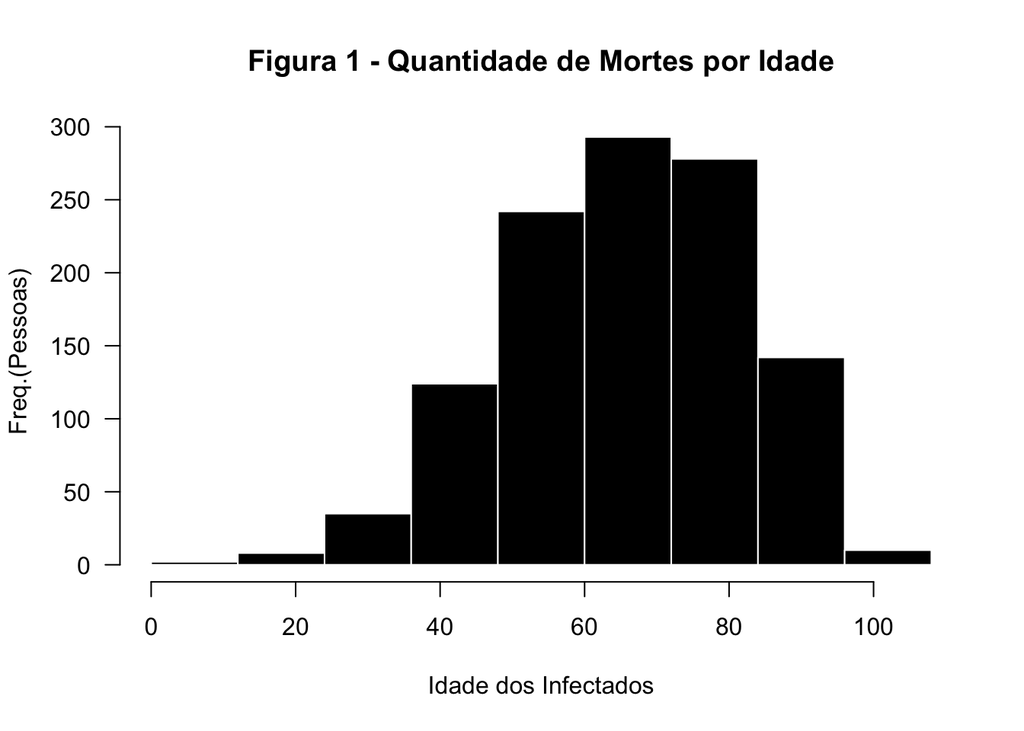

Descobriu-se, ao longo da pandemia, que a covid-19 é mais agressiva em pessoas com comorbidades. Na cidade de Bauru, verifica-se que as comorbidades mais presente entre os óbitos foram Diabetes, seguida de Hipertensão. Outras doenças como Cardiopatia, Obesidade e algumas doenças crônicas também se destacam. A Figura 2 mostra a relaçao comorbidade e óbitos onde: DNC = Doença Neurológica Crônica, DRC = Doença Renal Crônica e DCVC = Doença Cardiovascular Crônica.

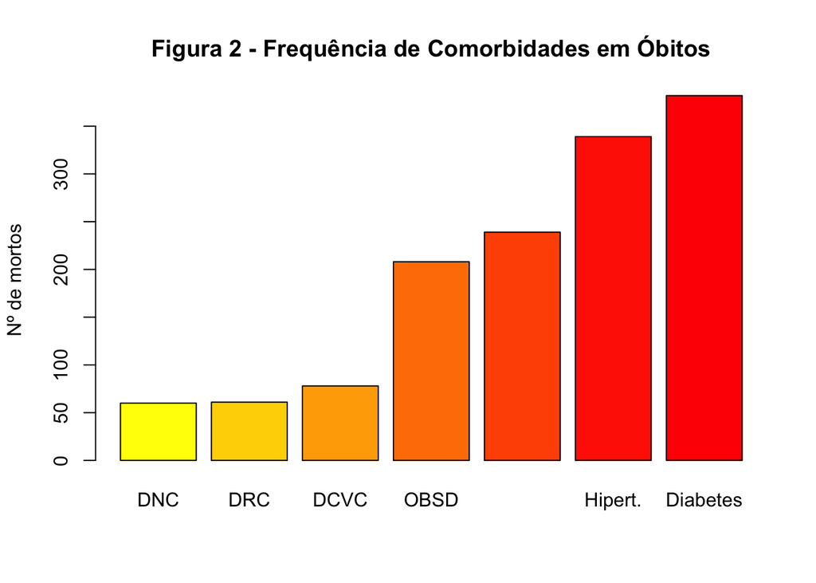

Sabe-se que a covid afeta variadamente cada infectado, e, por isso, sabemos que o tempo de internaçao até óbito ou cura variará também. Analisando os dados fornecidos, na cidade de Bauru, a maioria das internaçoes duraram entre 1-3 semanas (7-21 dias) antes do óbito. É o que mostra o gráfico da Figura 3.

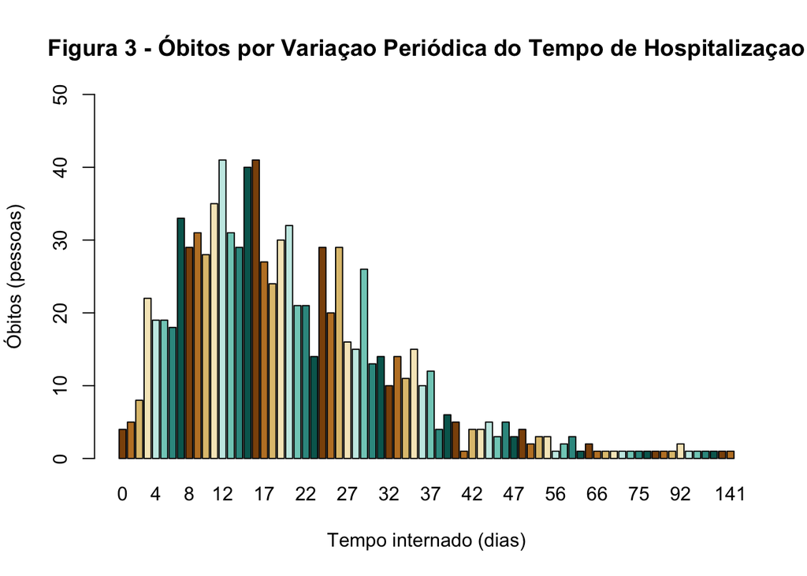

Agora, analisando a diferença da variaçao periódica de internaçao entre hospitais públicos e privados, percebemos, primeiramente, que há mais pessoas internadas em hospitais públicos do que privados, o que é de se esperar. Também vemos que nos hospitais públicos há uma concentração de pessoas que ficaram de 1-2 semanas internadas, enquanto nos privados o tempo é maior ficando entre 2 e 4 semanas. A análise é demonstrada na figura abaixo:

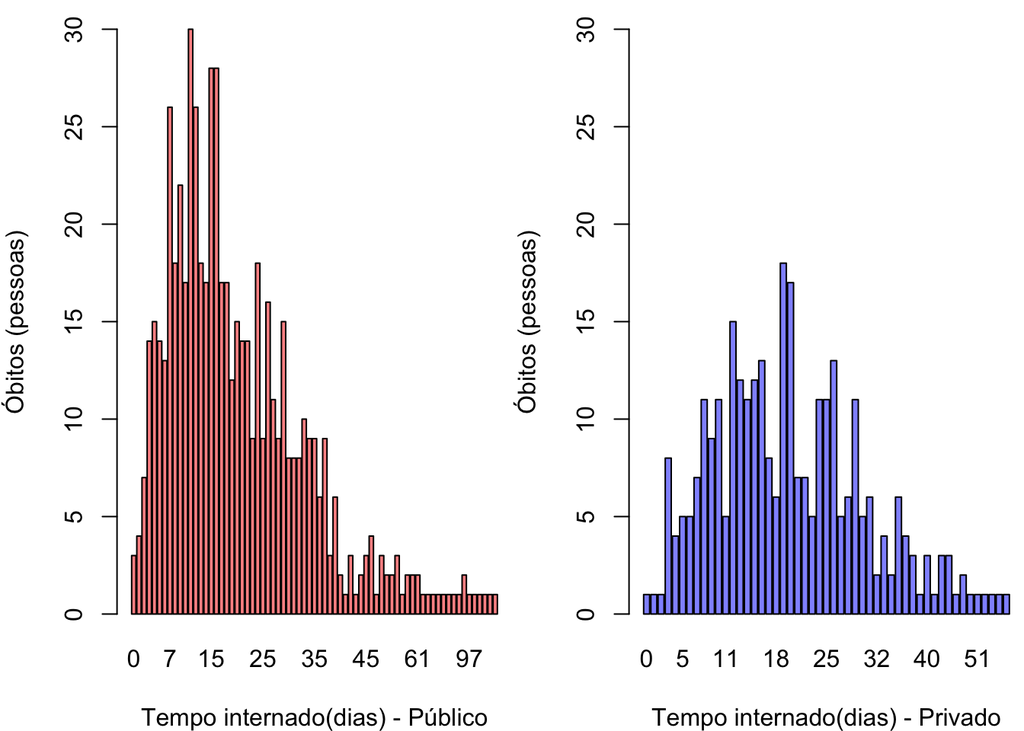